# Prova de Programação para Data Science e Data Analytics

- **Prof. Cleilton Lima Rocha**
- **emails:** climarocha@gmail.com
- **deadline: 11/3 às 23h**
- **Titulo do e-mail:** Prova de PDSDA [Fulane, Beltrano]
- **Conteúdo do e-mail:** Envie-me, obrigatoriamente, o código fonte e o report de todos os jupyters notebook (File ==> Download As ==> Html ou PDF), com o nome dos membros da dupla, para um dos meus emails, climarocha@gmail.com ou cleilton_rocha@atlantico.com.br até o dia **13/3 às 23h**, após esta data sua prova valerá no máximo **8 (oito pontos)**.
- **Respostas das questões:**
  - Quando você julgar necessário construa gráficos para responder as questões e explique-os de forma sucinta com clareza e objetividade. Isso lhe ajudará a se tornar um bom cientista de dados.
  - As questões podem ser respondidas utilizando o **Pyspark**, embora não seja obrigatório.

Qualquer dúvida podem me escrever!

### Descrição

Para facilitar a administração da segurança pública, o Departamento de Polícia de Seattle dividiu a cidade em 5 partes, cada uma com uma delegacia. Cada delegacia foi subdividida em setores, e estes foram divididos em *beats* (hondas). A administração tem dois *datasets* um chamado **Call_Data**, para obter maiores informações acesse este [link](https://data.seattle.gov/Public-Safety/Call-Data/33kz-ixgy) e outro chamado **Crime_Data**, maiores detalhes [aqui](https://data.seattle.gov/Public-Safety/Crime-Data/4fs7-3vj5) (acesse os links para compreender o dicionário de cada dataset).

O download do dataset de chamadas está disponível neste [link](https://data.seattle.gov/api/views/33kz-ixgy/rows.csv?accessType=DOWNLOAD) e o download do dataset de crimes está [aqui](https://data.seattle.gov/api/views/4fs7-3vj5/rows.csv?accessType=DOWNLOAD).

O administrador geral pediu que você, cientista de dados, o ajudasse a elaborar um report respondendo algumas perguntas. O objetivo deste projeto é ajudar a administração fornecendo informações relevantes para ajudá-los a resolver de forma mais rápida uma chamada, um crime ou mesmo replanejar a distribuição das hondas e setores. Como bom cientista de dados que você é, você tem a liberdade de ir além e responder mais perguntas do que as que estão aqui =D, através dos insights que vão surgindo a medida que você mergulha no problema.

**Boa prova e hands on!**

### Questões obrigatórias da avaliação

- Carreque o dataset de chamadas ...

```python
import pandas as pd
import seaborn as sns
import numpy as np
import matplotlib.pyplot as plt
%matplotlib inline
import warnings
from datetime import datetime
from dateutil.relativedelta import relativedelta
```

```python
call = pd.read_csv("Call_Data.csv")
call.info()
```

```
<class 'pandas.core.frame.DataFrame'>
RangeIndex: 3856726 entries, 0 to 3856725
Data columns (total 11 columns):
CAD Event Number               int64
Event Clearance Description    object
Call Type                      object
Priority                       int64
Initial Call Type              object
Final Call Type                object
Original Time Queued           object
Arrived Time                   object
Precinct                       object
Sector                         object
Beat                           object
dtypes: int64(2), object(9)
memory usage: 323.7+ MB
```

- Crie variáveis para representar o ano, mês, dia da semana e semana (por exemplo, 2_2018) para o dataset de chamadas.

```python
from datetime import datetime

def num_dia(dataVar):
    datetime_object = datetime.strptime(dataVar, '%m/%d/%Y %I:%M:%S %p')
    return datetime_object.day

def num_semana(dataVar):
    datetime_object = datetime.strptime(dataVar, '%m/%d/%Y %I:%M:%S %p')
    return str(datetime_object.isocalendar()[1]) + '_' + str(datetime_object.isocalendar()[0])

def num_ano(dataVar):
    datetime_object = datetime.strptime(dataVar, '%m/%d/%Y %I:%M:%S %p')
    return datetime_object.year

def num_mes(dataVar):
    datetime_object = datetime.strptime(dataVar, '%m/%d/%Y %I:%M:%S %p')
    return datetime_object.month

def dia_da_semana(dataVar):
    datetime_object = datetime.strptime(dataVar, '%m/%d/%Y %I:%M:%S %p')
    if datetime_object.isoweekday() == 1:
        return 'Monday'
    elif datetime_object.isoweekday() == 2:
        return 'Tuesday'
    elif datetime_object.isoweekday() == 3:
        return 'Wednesday'
    elif datetime_object.isoweekday() == 4:
        return 'Thursday'
    elif datetime_object.isoweekday() == 5:
        return 'Friday'
    elif datetime_object.isoweekday() == 6:
        return 'Saturday'
    elif datetime_object.isoweekday() == 7:
        return 'Sunday'
    else:
        return 'ERROR'

def periodo_dia(dataVar):
    datetime_object = datetime.strptime(dataVar, '%m/%d/%Y %I:%M:%S %p')
    if (datetime_object.hour < 6):
        return 'After Midnight'
    elif (datetime_object.hour < 12):
        return 'Morning'
    elif (datetime_object.hour < 18):
        return 'Afternoon'
    else:
        return 'Night'
```

```python
call['Week'] = call['Original Time Queued'].apply(lambda data: num_semana(data))
call['Year'] = call['Original Time Queued'].apply(lambda data: num_ano(data))
call['Month'] = call['Original Time Queued'].apply(lambda data: num_mes(data))
call['Day'] = call['Original Time Queued'].apply(lambda data: num_dia(data))
call['Weekday'] = call['Original Time Queued'].apply(lambda data: dia_da_semana(data))
call['Day Period'] = call['Original Time Queued'].apply(lambda data: periodo_dia(data))
```

- Elimine os registros cujo precint, setor ou beat seja nulo.

```python
call_len = len(call)

call.drop(call[call['Precinct'].isnull() | call['Beat'].isnull() | call['Sector'].isnull()].index, inplace=True)

print('Registros eliminados de \'call\':  %i' % (call_len - len(call)))
```

```
Registros eliminados de 'call':  36509
```

- Qual delegacia tem mais setores? E qual tem mais beats?

```python
call_precinct_s = call.groupby(['Precinct'])['Sector'].nunique()

call_precinct_b = call.groupby(['Precinct'])['Beat'].nunique()

print('A delegacia com mais setores é %s, e a com mais beats é %s' % (call_precinct_s.idxmax(), call_precinct_b.idxmax()))
```

```
A delegacia com mais setores é NORTH, e a com mais beats é NORTH
```

- Apresente a evolução do número de chamadas, escolha 3 tipos de chamadas, ao longo dos últimos 10 anos.

```python
call_tipo = call.groupby('Call Type').count().reset_index()
print('Esses são os 3 principais tipo de ligações e sua quantidade')

call_tipo.rename(index=str, columns={'CAD Event Number': 'Total'}, inplace=True)
call_tipo.sort_values('Total', ascending=False).reset_index()[['Call Type','Total']].head(3)
```

```
Esses são os 3 principais tipo de ligações e sua quantidade
```

|  | Call Type | Total |
| --- | --- | --- |
| 0 | ONVIEW | 1529312 |
| 1 | 911 | 1294109 |
| 2 | TELEPHONE OTHER, NOT 911 | 885041 |

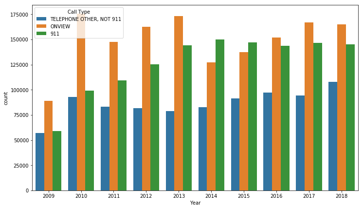

```python
call_10 = call[((call['Year'] >= 2008) & (call['Year'] <= 2018)) &
               ((call['Call Type'] == '911') |
                (call['Call Type'] == 'ONVIEW') |
                (call['Call Type'] == 'TELEPHONE OTHER, NOT 911') )]

call_10.reset_index(inplace=True)

plt.figure(figsize=[12,7])
sns.countplot(x='Year', hue='Call Type', data=call_10)
```

#### R: Constatamos que as chamadas do tipo ONVIEW tiveram um pico em 2010, caíram em 2011 e cresceram até 2013, depois caíram novamente e cresceram até 2017, mantendo uma constância em 2018

#### As chamadas do tipo 911foram crescendo até 2014 quando passaram a ter uma quantidade bem próxima nos anos seguintes.

#### Já os telefones que não são 911 tiveram números oscilantes nos últimos 10 anos. Notamos, porém o distanciamento desse tipo de chamada com os passar dos anos para os números de chamadas 911.

- A delegacia que possui mais setores é a que mais recebe chamadas? Justifique sua resposta.

```python
call_precinct_s = call.groupby(['Precinct'])['Sector'].nunique().reset_index()
call_qtd = call.groupby('Precinct').size().reset_index()
call_precinct_s.sort_values('Sector', ascending=False, inplace=True)

call_qtd.rename(index=str, columns={0: 'Numero de Chamadas'}, inplace=True)
call_qtd.sort_values('Numero de Chamadas', ascending=False, inplace=True)
```

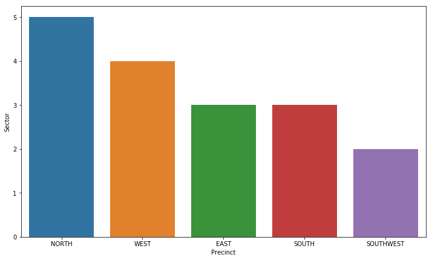

```python
plt.figure(figsize=[12,7])
sns.barplot(data=call_precinct_s, x='Precinct', y='Sector')
```

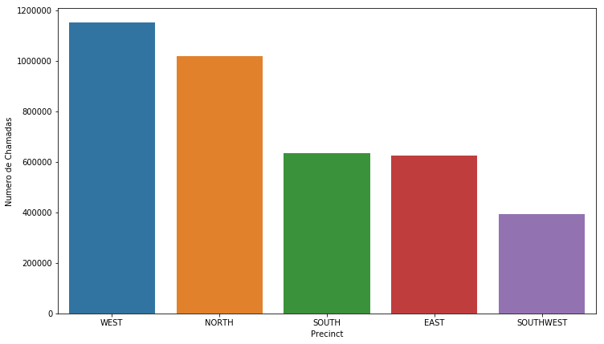

```python
plt.figure(figsize=[12,7])
sns.barplot(data=call_qtd, x='Precinct', y='Numero de Chamadas')
```

#### R: O Precinct com o maior número de Sectors é NORTH, porém o que possui mais ligações e WEST.]

- Apresente o ranking dos setores, no máximo 10, considerando o percentual de chamadas fraudulentas "FALSE COMPLAINT/UNFOUNDED".

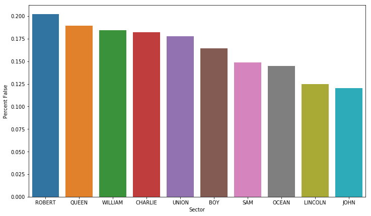

```python
call['False Call'] = call['Event Clearance Description'] == 'FALSE COMPLAINT/UNFOUNDED'
total_call = call['Event Clearance Description'].count()
call_false = call.groupby('Sector').sum()
call_false['Percent False'] = (call_false['False Call']/total_call)*100
call_false.sort_values(by=['False Call'], ascending=False, inplace=True)
call_false = call_false.reset_index().head(10)

plt.figure(figsize=[12,7])
sns.barplot(x='Sector', y='Percent False', data=call_false)
```

- Com relação à distribuição das chamadas fraudulentas no tempo, é possível observar momentos dentro dos dias ou dias da semana onde chamadas deste tipo tem maiores chances de ocorrerem?

```python
false_call_day = call.groupby(['Month','Day']).sum().reset_index()[['Month','Day','False Call']].sort_values(by=['False Call'], ascending=False)
false_call_day.head()
```

|  | Month | Day | False Call |
| --- | --- | --- | --- |
| 185 | 7 | 4 | 374.0 |
| 184 | 7 | 3 | 344.0 |
| 187 | 7 | 6 | 324.0 |
| 330 | 11 | 26 | 316.0 |
| 208 | 7 | 27 | 310.0 |

#### R: O Dia do ano que possui mais ligações falsa são os dias próximos as feriado de 4 de Julho, dia da Independência

```python
false_call_per_week = call.groupby(['Weekday','Day Period']).sum().reset_index()[['Weekday','Day Period','False Call']].sort_values(by=['False Call'], ascending=False)

false_call_per_week.head()
```

|  | Weekday | Day Period | False Call |
| --- | --- | --- | --- |
| 10 | Saturday | Morning | 3750.0 |
| 9 | Saturday | Afternoon | 3680.0 |
| 2 | Friday | Morning | 3668.0 |
| 18 | Thursday | Morning | 3664.0 |
| 26 | Wednesday | Morning | 3601.0 |

#### R: Numa análise agrupoando por período do dia e dias da semana, as chamadas fraudulentas costumam ocorrer com mais frequências aos sábados entre 6:00 e 18:00

- Qual o dia em que ocorrem mais chamadas? E qual o tipo de chamada mais recorrente nesse dia? Como esse tipo de chamada evoluiu ao longo dos últimos 5 anos?

```python
call_type_day = call.groupby(['Year','Month','Day']).count().reset_index().sort_values(by=['CAD Event Number'], ascending=False)
call_type_day.rename(index=str, columns={'CAD Event Number': 'Total'}, inplace=True)
print('Esse é o dia com a maior quantidade de chamadas:')
call_type_day.head(1)[['Day','Month','Year','Total']]
```

```
Esse é o dia com a maior quantidade de chamadas:
```

|  | Day | Month | Year | Total |
| --- | --- | --- | --- | --- |
| 3482 | 14 | 12 | 2018 | 1494 |

```python
call_type = call[(call['Year'] == 2018) & (call['Month'] == 12) & (call['Day'] == 14)].reset_index()
call_type = call_type.groupby('Initial Call Type').count().reset_index().sort_values(by=['index'], ascending=False)
call_type.rename(index=str, columns={'CAD Event Number': 'Total'}, inplace=True)
print('Essa é a chamada com a maior quantidade no dia:')
call_type[['Initial Call Type', 'Total']].head(1)
```

```
Essa é a chamada com a maior quantidade no dia:
```

|  | Initial Call Type | Total |
| --- | --- | --- |
| 84 | PREMISE CHECK, OFFICER INITIATED ONVIEW ONLY | 119 |

```
Ao longo dos últimos 5 anos (excluíndo 2019), foi assim que essa chamada evoluiu:
```

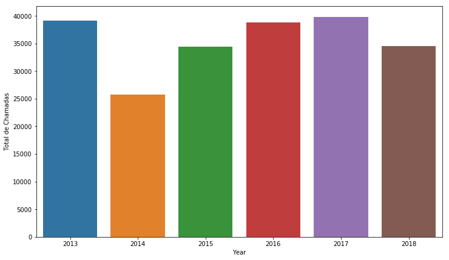

```python
call_5 = call[(call['Year'] >= 2013) & (call['Year'] < 2019)  & (call['Initial Call Type'] == 'PREMISE CHECK, OFFICER INITIATED ONVIEW ONLY')]
call_5 = call_5.groupby('Year').count().reset_index()[['Year', 'Initial Call Type']]
call_5.rename(index=str, columns={'Initial Call Type': 'Total de Chamadas'}, inplace=True)

print('Ao longo dos últimos 5 anos (excluíndo 2019), foi assim que essa chamada evoluiu:')
plt.figure(figsize=[12,7])
sns.barplot(x='Year', y='Total de Chamadas', data=call_5)
```

- Quais chamadas são *outliers* nos últimos 5 anos? Considere como *outlier* as chamadas fora do intervalo de 1,5 da distância inter quartil (Q3-Q1). O que você pode concluir desta informação?

```python
def outline(call, mean, std):
    upper = mean + std
    return call > upper
```

```python
callOutline = call[(call['Year'] >= 2013) & (call['Year']) < 2018 ]
callOutline = callOutline.groupby('Initial Call Type').count().reset_index()
callOutline = callOutline[['Initial Call Type','CAD Event Number']]
callOutline.rename(index=str, columns={'CAD Event Number': 'Total'}, inplace=True)

std = callOutline['Total'].std()
mean = callOutline['Total'].mean()

callOutlineStd = callOutline[callOutline['Total'].apply(outline, args = (mean, std))]

callOutlineStd.sort_values('Total', ascending=False).reset_index()[['Initial Call Type','Total']]
```

|  | Initial Call Type | Total |
| --- | --- | --- |
| 0 | PREMISE CHECK, OFFICER INITIATED ONVIEW ONLY | 356157 |
| 1 | SUSPICIOUS PERSON, VEHICLE OR INCIDENT | 233365 |
| 2 | TRAFFIC STOP - OFFICER INITIATED ONVIEW | 227665 |
| 3 | PARKING VIOLATION (EXCEPT ABANDONED CAR) | 190733 |
| 4 | DISTURBANCE, MISCELLANEOUS/OTHER | 186375 |
| 5 | SUSPICIOUS STOP - OFFICER INITIATED ONVIEW | 156749 |
| 6 | THEFT (DOES NOT INCLUDE SHOPLIFT OR SVCS) | 103496 |
| 7 | DIRECTED PATROL ACTIVITY | 98226 |
| 8 | FOLLOW UP | 77050 |
| 9 | OFF DUTY EMPLOYMENT | 75111 |
| 10 | NUISANCE - MISCHIEF | 68333 |
| 11 | TRESPASS | 64088 |
| 12 | ALARM - RESIDENTIAL - BURGLARY, SILENT/AUDIBLE | 56175 |
| 13 | BURG - RES (INCL UNOCC STRUCTURES ON PROP) | 55480 |
| 14 | NARCOTICS - VIOLATIONS (LOITER, USE, SELL, NARS) | 55211 |
| 15 | SHOPLIFT - THEFT | 52144 |
| 16 | ALARM - COMM, SILENT/AUD BURG (INCL BANKS) | 50091 |

```python
totalTudo = callOutline['Total'].count()
somaTudo = callOutline['Total'].sum()
totalOutline = callOutlineStd['Total'].count()
somaOutline = callOutlineStd['Total'].sum()

print('Nesses 5 anos foram feitos %s tipos de ligações diferentes totalizando %s ligações ' % (totalTudo, somaTudo))
print('Considerando os outlines, nesses 5 anos foram feitos %s tipos de ligações, somando %s ligações. ' % (totalOutline, somaOutline))
print('Constatamos que a quantidade de ligações outlines nesse perioso representa %0.2f%% das ligações feitas.' % (somaOutline/somaTudo*100))
```

[output not shown]

- Quais as chamadas tem recebido mais atenção da polícia nos últimos 5 anos, considere a prioridade?

```python
def time_diff(inicio, fim):
    datetime_inicio = datetime.strptime(inicio, '%m/%d/%Y %I:%M:%S %p')
    datetime_fim = datetime.strptime(fim, '%b %d %Y %I:%M:%S:%f%p')

    if datetime_fim >= datetime_inicio:
        diferenca = datetime_fim - datetime_inicio
    else:
        diferenca = -1
    return diferenca
```

```python
call['Call Difference'] = call.apply(lambda data: time_diff(data['Original Time Queued'], data['Arrived Time']), axis=1)
```

```python
call_diff = call[ (call['Year'] >= 2013)]
call_diff = call_diff[call_diff['Call Difference'] != -1 ]
```

```python
call_diff_gb = call_diff.groupby(['Priority', 'Initial Call Type']).max().reset_index()
call_diff_gb.sort_values(by=['Priority','Call Difference'], ascending=[False,True], inplace=True)
print('Essas são as top 10 chamadas que receberam maior atenção nos últimos 10 anos.')
print('O critério de atenção usado foi o tempo levado entre a chamada e a chegada dos policiais')
call_diff_gb.head(10).reset_index()['Initial Call Type']
```

[output not shown]

```
0              --FRAUD - FRAUD, INCLUDING BUNCO
1                   -DOWN TIME - OUT OF SERVICE
2                                 -OUT AT RANGE
3    --ALARM-COMM (INC BANK, ATM, SCHOOLS, BSN)
4                  --TRAFFIC - BLOCKING TRAFFIC
5                      -ELEMENTARY SCHOOL VISIT
6                   -OUT OF CAR/NO REASON GIVEN
7                        -ASSIGNED DUTY - COURT
8                  -GAS/MAINTENANCE/WASH/GARAGE
9                    ALARM - NO RESPONSE STATUS
Name: Initial Call Type, dtype: object
```

- Apresente o ranking das 10 chamadas mais relevantes no ano de 2018.

```
Essas são as top 10 chamadas mais relevantes de 2018.
O critério de relevancia foia a quantidade de chamadas feitas no ano.
```

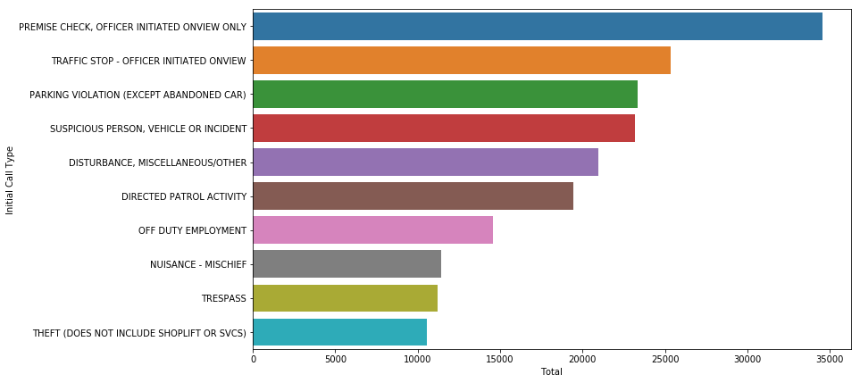

```python
call_2018 = call[call['Year'] == 2018]
call_2018gb = call_2018.groupby('Initial Call Type').count().reset_index()
call_2018gb10 = call_2018gb.sort_values('CAD Event Number', ascending=False).head(10).reset_index()
call_2018gb10.rename(index=str, columns={'CAD Event Number': 'Total'}, inplace=True)


print('Essas são as top 10 chamadas mais relevantes de 2018.')
print('O critério de relevancia foia a quantidade de chamadas feitas no ano.')

plt.figure(figsize=[12,7])
sns.barplot(x='Total' , y='Initial Call Type',data=call_2018gb10 )
```

- Quais as chamadas que mais demoram para serem atendidas? Há alguma relação com a prioridade?

```python
callDemora = call[call['Call Difference'] != -1 ]
callDemora = callDemora.sort_values('Call Difference', ascending=False)
callDemora[['Initial Call Type','Priority','Call Difference']].head(10)
```

|  | Initial Call Type | Priority | Call Difference |
| --- | --- | --- | --- |
| 1586055 | ACC - REPORT, NON INJ/NON BLKG OR AFTER FACT INJ | 3 | 43 days, 21:19:10 |
| 659570 | PARKING VIOLATION (EXCEPT ABANDONED CAR) | 3 | 39 days, 23:16:12 |
| 2585101 | POWER OUT - POLES AND TRANSFORMERS | 3 | 23 days, 0:58:25 |
| 1270893 | AUTO THEFT - VEH THEFT OR THEFT & RECOVERY | 3 | 14 days, 16:55:52 |
| 421169 | PROPERTY - LOST OR MISSING | 4 | 12 days, 3:54:55 |
| 1595130 | DISTURBANCE, MISCELLANEOUS/OTHER | 2 | 10 days, 18:58:04 |
| 139711 | DISTURBANCE, MISCELLANEOUS/OTHER | 3 | 8 days, 8:01:45 |
| 2199052 | SUSPICIOUS PERSON, VEHICLE OR INCIDENT | 3 | 7 days, 14:27:01 |
| 3400059 | INFORMATIONAL BROADCASTS | 4 | 7 days, 7:35:07 |
| 1653773 | RAPE | 3 | 5 days, 22:19:52 |

#### R: Podemos observar que as chamadas com maior tempo de atendimento são as que possuem prioridade média-baixa

- Qual é a chamada com mais enganos, ou seja, aquelas que mais mudam de classificação entre o início da chamada e o final da chamada?

```
Essas são os 5 tipos de chamadas que mudam o sua classificação inicial:
```

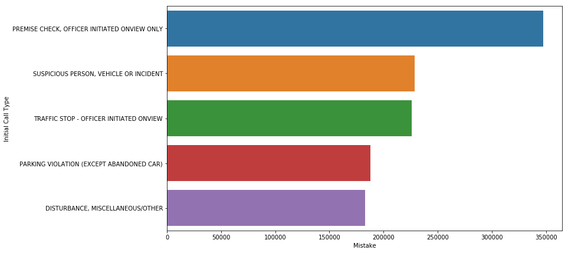

```python
call['Mistake'] = (call['Initial Call Type'] != call['Final Call Type'])

call_mistake = call[['Initial Call Type','Final Call Type','Mistake']]

call_mistake = call_mistake.groupby(['Initial Call Type']).sum().reset_index()

call_mistake.sort_values(by=['Mistake'], ascending=False, inplace=True)

call_mistake_5 = call_mistake.head(5)
print('Essas são os 5 tipos de chamadas que mudam o sua classificação inicial: ')
plt.figure(figsize=[12,7])
sns.barplot(y='Initial Call Type', x='Mistake', data=call_mistake_5)
```

- O número médio de chamadas ao longo dos anos por delegacia tem aumentado ou diminuído?

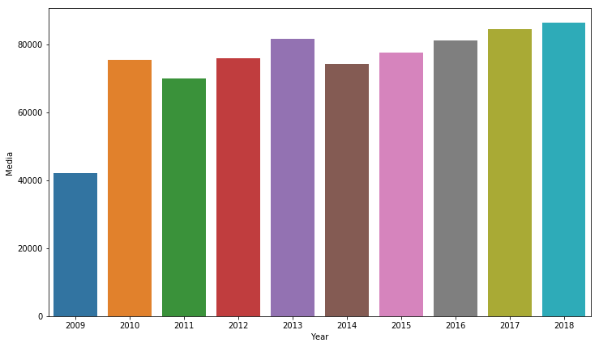

```python
call['Media'] = 1
callYear = call[call['Year'] < 2019].groupby(['Year','Precinct']).sum().reset_index()
callMeanYear = callYear.groupby('Year').mean().reset_index()
plt.figure(figsize=[12,7])
sns.barplot(data=callMeanYear, x='Year', y='Media')
```

#### R: Após um pico na média de chamadas por delegacia em 2010 ocorreu uma queda com um aumento gradativo até 2013. Uma nova queda ocorre em 2014, seguindo de um novo crescimento gradual.

- Carregue o data set de crimes e elimine todos os elementos que possuam valores nulos.

```python
df_crime = pd.read_csv("Crime_Data.csv")
```

```python
df_crime.info()
```

```
<class 'pandas.core.frame.DataFrame'>
RangeIndex: 514285 entries, 0 to 514284
Data columns (total 11 columns):
Report Number                  514285 non-null int64
Occurred Date                  514283 non-null object
Occurred Time                  514283 non-null float64
Reported Date                  514285 non-null object
Reported Time                  514283 non-null float64
Crime Subcategory              514023 non-null object
Primary Offense Description    514285 non-null object
Precinct                       514279 non-null object
Sector                         511001 non-null object
Beat                           511049 non-null object
Neighborhood                   514285 non-null object
dtypes: float64(2), int64(1), object(8)
memory usage: 43.2+ MB
```

```python
df_crime.head()
```

|  | Report Number | Occurred Date | Occurred Time | Reported Date | Reported Time | Crime Subcategory | Primary Offense Description | Precinct | Sector | Beat | Neighborhood |
| --- | --- | --- | --- | --- | --- | --- | --- | --- | --- | --- | --- |
| 0 | 1975000079415 | 12/16/1975 | 900.0 | 12/16/1975 | 1500.0 | BURGLARY-RESIDENTIAL | BURGLARY-FORCE-RES | SOUTH | R | R3 | LAKEWOOD/SEWARD PARK |
| 1 | 1976000069169 | 01/01/1976 | 1.0 | 01/31/1976 | 2359.0 | SEX OFFENSE-OTHER | SEXOFF-INDECENT LIBERTIES | UNKNOWN | NaN | NaN | UNKNOWN |
| 2 | 1979000049118 | 01/28/1979 | 1600.0 | 02/09/1979 | 1430.0 | CAR PROWL | THEFT-CARPROWL | EAST | G | G2 | CENTRAL AREA/SQUIRE PARK |
| 3 | 19810000305573 | 08/22/1981 | 2029.0 | 08/22/1981 | 2030.0 | HOMICIDE | HOMICIDE-PREMEDITATED-WEAPON | SOUTH | S | S2 | BRIGHTON/DUNLAP |
| 4 | 1981000076456 | 02/14/1981 | 2000.0 | 02/15/1981 | 435.0 | BURGLARY-RESIDENTIAL | BURGLARY-FORCE-RES | SOUTHWEST | W | W3 | ROXHILL/WESTWOOD/ARBOR HEIGHTS |

```python
len_crime_all = len(df_crime)
df_crime = df_crime.dropna()

print('Registros eliminados de \'crime\':  %i' % (len_crime_all - len(df_crime)))
```

```
Registros eliminados de 'crime':  3552
```

- Qual o ranking dos 10 crimes que mais ocorreu em seattle nos últimos 3 anos?

```python
data_3anos_atras = datetime.now() - relativedelta(years=3)
df_crime_3anos = df_crime[pd.to_datetime(df_crime["Occurred Date"]) > data_3anos_atras]

top10_Crimes = df_crime_3anos.groupby("Primary Offense Description").count().reset_index().sort_values(by=['Report Number'],ascending=False)
top10_Crimes["Primary Offense Description"].sort_values(ascending=False).head(10)
```

```
131         WEAPON-UNLAWFUL USE
130           WEAPON-POSSESSION
129            WEAPON-DISCHARGE
128            WEAPON-CONCEALED
127             VEH-THEFT-TRUCK
126           VEH-THEFT-TRAILER
125    VEH-THEFT-RECREATION VEH
124            VEH-THEFT-OTHVEH
123          VEH-THEFT-MTRCYCLE
122          VEH-THEFT-HVYEQUIP
Name: Primary Offense Description, dtype: object
```

- Qual o setor, a região e o beat mais perigoso, considerando o número total de crimes? E qual crime mais se destacou no setor?

```python
count_crimes_sector = df_crime.groupby("Sector").count().reset_index().sort_values(by=['Report Number'],ascending=False)
count_crimes_neighborhood = df_crime.groupby("Neighborhood").count().reset_index().sort_values(by=['Report Number'],ascending=False)
count_crimes_beat = df_crime.groupby("Beat").count().reset_index().sort_values(by=['Report Number'],ascending=False)
```

```python
top1_setor_crimes = count_crimes_sector["Sector"].sort_values(ascending=False).head(1)
top1_setor_crimes
```

```
16    W
Name: Sector, dtype: object
```

```python
top1_neighborhood_crimes = count_crimes_neighborhood["Neighborhood"].sort_values(ascending=False).head(1)
top1_neighborhood_crimes
```

```
58    WALLINGFORD
Name: Neighborhood, dtype: object
```

```python
top1_beat_crimes = count_crimes_beat["Beat"].sort_values(ascending=False).head(1)
top1_beat_crimes
```

```
50    W3
Name: Beat, dtype: object
```

```python
count_crimes_top1_setor = df_crime[df_crime["Sector"] == "W"].groupby("Primary Offense Description").count().reset_index().sort_values(by=['Report Number'],ascending=False)
count_crimes_top1_setor

top1_crimes_top1_sector = count_crimes_top1_setor["Primary Offense Description"].sort_values(ascending=False).head(1)
top1_crimes_top1_sector
```

```
115    WEAPON-UNLAWFUL USE
Name: Primary Offense Description, dtype: object
```

- Crie variáveis para representar o ano, mês, dia da semana e semana (por exemplo, 2_2018) para o dataset de crimes.

```python
df_crime['Year'] = df_crime["Occurred Date"].apply(lambda data: pd.to_datetime(data).year)
df_crime['Month'] = df_crime["Occurred Date"].apply(lambda data: pd.to_datetime(data).month)
df_crime['Weekday'] = df_crime["Occurred Date"].apply(lambda data: pd.to_datetime(data).weekday)
df_crime['Week'] = df_crime["Occurred Date"].apply(lambda data: pd.to_datetime(data).week)
```

```python
df_crime.info()
```

```
<class 'pandas.core.frame.DataFrame'>
Int64Index: 510733 entries, 0 to 514284
Data columns (total 15 columns):
Report Number                  510733 non-null int64
Occurred Date                  510733 non-null object
Occurred Time                  510733 non-null float64
Reported Date                  510733 non-null object
Reported Time                  510733 non-null float64
Crime Subcategory              510733 non-null object
Primary Offense Description    510733 non-null object
Precinct                       510733 non-null object
Sector                         510733 non-null object
Beat                           510733 non-null object
Neighborhood                   510733 non-null object
Year                           510733 non-null int64
Month                          510733 non-null int64
Weekday                        510733 non-null object
Week                           510733 non-null int64
dtypes: float64(2), int64(4), object(9)
memory usage: 62.3+ MB
```

- Realize o join do dataset de chamadas com o dataset de crimes considerando os últimos 10 anos. *P.S.:* Observe as chaves de integração.

```python
df_chamadas_crimes = call.join(df_crime.set_index("Report Number"), on="CAD Event Number", lsuffix='_chamada', rsuffix='_crime')

df_chamadas_crimes = df_chamadas_crimes[df_chamadas_crimes["Year_crime"] >= datetime.now().year - 5]
df_chamadas_crimes.info()
```

```
<class 'pandas.core.frame.DataFrame'>
Int64Index: 43731 entries, 1675276 to 3841563
Data columns (total 35 columns):
CAD Event Number               43731 non-null int64
Event Clearance Description    43731 non-null object
Call Type                      43731 non-null object
Priority                       43731 non-null int64
Initial Call Type              43731 non-null object
Final Call Type                43731 non-null object
Original Time Queued           43731 non-null object
Arrived Time                   43731 non-null object
Precinct_chamada               43731 non-null object
Sector_chamada                 43731 non-null object
Beat_chamada                   43731 non-null object
Week_chamada                   43731 non-null object
Year_chamada                   43731 non-null int64
Month_chamada                  43731 non-null int64
Day                            43731 non-null int64
Weekday_chamada                43731 non-null object
Day Period                     43731 non-null object
False Call                     43731 non-null bool
Call Difference                43731 non-null object
Mistake                        43731 non-null bool
Media                          43731 non-null int64
Occurred Date                  43731 non-null object
Occurred Time                  43731 non-null float64
Reported Date                  43731 non-null object
Reported Time                  43731 non-null float64
Crime Subcategory              43731 non-null object
Primary Offense Description    43731 non-null object
Precinct_crime                 43731 non-null object
Sector_crime                   43731 non-null object
Beat_crime                     43731 non-null object
Neighborhood                   43731 non-null object
Year_crime                     43731 non-null float64
Month_crime                    43731 non-null float64
Weekday_crime                  43731 non-null object
Week_crime                     43731 non-null float64
dtypes: bool(2), float64(5), int64(6), object(22)
memory usage: 11.4+ MB
```

- Existe alguma relação do número de crimes com o número de chamadas, considerando os últimos 5 anos?
- Qual o ano mais violento considerando o total de crimes?

```python
TotalCrime = df_crime.count()
crimeAno = df_crime.groupby('Year').count().reset_index()

crimeAno.rename(index=str, columns={'Report Number': 'Total'}, inplace=True)

crimeAno = crimeAno[['Year','Total']]
crimeAno = crimeAno.sort_values('Total', ascending=False)
print('Esse é o Top 10 de anos mais violentos baseados no número de crimes:')
crimeAno.head(10).reset_index()[['Year','Total']]
```

```
Esse é o Top 10 de anos mais violentos baseados no número de crimes:
```

|  | Year | Total |
| --- | --- | --- |
| 0 | 2018 | 50844 |
| 1 | 2017 | 49949 |
| 2 | 2014 | 49096 |
| 3 | 2016 | 48951 |
| 4 | 2015 | 47489 |
| 5 | 2013 | 45258 |
| 6 | 2009 | 44730 |
| 7 | 2010 | 43032 |
| 8 | 2008 | 42267 |
| 9 | 2011 | 41016 |

- Qual o mês, semana e dia mais violento dos últimos 5 anos, considerando o número de crimes e o número de chamadas?

```python
crime5 = df_crime[(df_crime['Year'] >= 2013) & (df_crime['Year'] < 2019)]
crimeMes = crime5.groupby(['Year','Month']).count()
crimeMes.rename(index=str, columns={'Report Number': 'Total'}, inplace=True)
crimeMes.sort_values('Total', ascending=False)['Total'].head(1)
```

```
Year  Month
2017  8        4524
Name: Total, dtype: int64
```

#### R: O Mês mais violento foi Agosto de 2017

```python
crimeSemana = crime5.groupby(['Year','Week']).count()
crimeSemana.rename(index=str, columns={'Report Number': 'Total'}, inplace=True)
crimeSemana.sort_values('Total', ascending=False)['Total'].head(1)
```

```
Year  Week
2018  1       1133
Name: Total, dtype: int64
```

#### R: A semana mais violenta foi a primeira semana de 2018, tendo ocorrido 1133 crimes registrados

```python
crimeDia = crime5.groupby(['Reported Date']).count()
crimeDia.rename(index=str, columns={'Report Number': 'Total'}, inplace=True)
crimeDia.sort_values('Total', ascending=False)['Total'].head(1)
```

```
Reported Date
03/31/2014    194
Name: Total, dtype: int64
```

#### R: O dia mais violento, com 194 crimes registrados, foi o dia 31 de Março de 2014

- Crie no mínimo 2 gráficos sobre quaisquer perguntas que você queira responder, considerando o dataset de crimes e explique-os de forma suscinta.

#### Pergunta 1: Qual o horário mais violendo de algum Setor?

```python
def periodoDia(time):
    if time < 300:
        return 0
    elif time < 600:
        return 1
    elif time < 900:
        return 2
    elif time < 1200:
        return 3
    elif time < 1500:
        return 4
    elif time < 1800:
        return 5
    elif time < 2100:
        return 6
    else:
        return 7
```

```python
df_crime['Hora do Dia'] = df_crime['Occurred Time'].apply(lambda time: periodoDia(time))
```

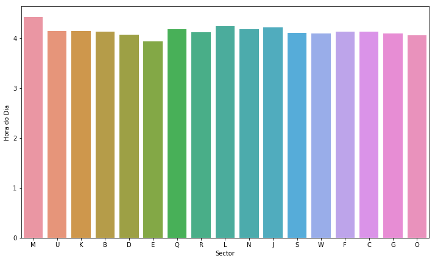

```python
crimeSetor = df_crime.groupby('Sector').agg({'Report Number': 'count', 'Hora do Dia': 'mean'})

crimeSetor = crimeSetor.sort_values('Report Number', ascending=False).reset_index()

plt.figure(figsize=[12,7])
sns.barplot(data=crimeSetor, x='Sector', y='Hora do Dia')
```

#### R:

#### Primeiramente classificamos os horários do dia em 8 categorias a cada 3 horas.

#### Depois de somar a quantidade de crimes em um setor, tiramos a média desses horários categorizados, afim de saber dentro de qual categoria de horário os crimes costumam acontecer mais.

#### Pudemos contatar que as maioria das ocorrencia é próximo ao horário de 15:00, limite superior da categoria 4.

```python
crimeSetor.head(1)
```

|  | Sector | Report Number | Hora do Dia |
| --- | --- | --- | --- |
| 0 | M | 42255 | 4.416732 |

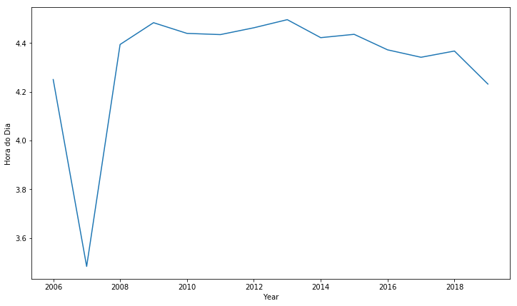

```python
crimeSetorAno = df_crime[(df_crime['Sector'] == 'M') & (df_crime['Year'] > 2005)].groupby(['Sector','Year']).agg({'Report Number': 'count', 'Hora do Dia': 'mean'})

crimeSetorAno = crimeSetorAno.sort_values('Report Number', ascending=False).reset_index()

plt.figure(figsize=[12,7])
sns.lineplot(data=crimeSetorAno, x='Year', y='Hora do Dia')
```

- Crie no mínimo 2 gráficos sobre quaisquer perguntas que você queira responder, considerando o dataset de crimes e chamadas juntas e explique-os de forma suscinta.
- Crie um pacote em python com o nome **help_seattle**, contendo outro pacote chamado **seattle_info**, e este contendo um módulo com informações do dataset de **chamadas** e outro módulo contendo informações do dataset de **crimes** módulo para responder no mínimo 3 das perguntas acima.
- Em sala estudamos sobre módulos e pacotes em Python. Este é o exercício passado em sala de aula e que deve ser entregue junto com a avaliação.
  - Crie um pacote banco que:
    - Crie um pacote que cadastre contas de pessoas físicas e jurídicas
    - Crie um pacote que conceda empréstimos e informe o valor da prestação considerando:
      - 10% de juros do empréstimo mais 0,5% do número de prestações para pessoas físicas
      - 5% de juros do empréstimo mais 0,3% do número de prestações para pessoas físicas
    - Crie um módulo para realizar as operações de saque, deposito e transferencia, cobrança de tarifa, R\$-20,00 para PF e R\\$: 10,00 para PF
    - Simule o lucro total do banco considerando o pagamento da tarifa de todos os clientes e os empréstimos realizados.
    - Crie um script em python ou um jupyter notebook que demostre a utilização do pacote

#### R: Arquivo com o script e os arquivos enviados compactados em anexo.

### Desafios

#### Desafio 1 (+3 Pontos extras)

- Faça este [curso online](https://www.datacamp.com/community/open-courses/introducao-a-r) e gratuito de introdução ao R e salve todos o hands on em úm unico script ou arquivo jupyter notebook
- Baixe e configure o R studio seguindo as instruções desse [tutorial](https://campus.datacamp.com/courses/introducao-a-r/capitulo-1-introducao-ao-basico?ex=1)
- Se quiser você pode baixar o R Studio a partir do Anaconda Navigator e utilizar no Jupyter notebook. Veja [aqui](https://docs.anaconda.com/anaconda/navigator/tutorials/r-lang/) algumas dicas

#### R: Script com o curso enviado em anexo

#### Desafio 2 (+1,5 Ponto extra)

- Crie um spark-job que calcule o número de chamadas feitas de alguma forma através do 911 (considere a programação utilizando **RDD**). Liste o setor, a região e o beat com maior número de chamadas 911? Veja o exemplo de um spark-job no nosso material.

```python
import csv
```

```python
with open("Call_Data.csv", "r", newline="") as f1:
    reader = csv.reader(f1, delimiter=",")
    with open("Call_Data_New.csv", "w", newline="") as f2:
        writer = csv.writer(f2)
        for row in reader:
            new_row = [col.replace(",", " -") for col in row]
            writer.writerow(new_row)
```

Esse procedimento elimina as vírgulas dentro das aspas que causam problema no PySpark ao separar as colunas por usar ',' como delimitador de coluna.

```python
import findspark
findspark.init()
```

```python
import pyspark
from pyspark.sql import SparkSession
from pyspark.sql import DataFrame, Row
from pyspark.sql import functions as F
from pyspark.sql.types import *
```

```python
spark = SparkSession.builder \
   .master("local") \
   .appName("Prova PDSDA") \
   .config("spark.executor.memory", "2gb") \
   .getOrCreate()

sc = spark.sparkContext
```

```python
FILE_CALL_PATH = 'Call_Data_New.csv'
rdd = sc.textFile(FILE_CALL_PATH)
rdd.take(1)
```

```
['CAD Event Number,Event Clearance Description,Call Type,Priority,Initial Call Type,Final Call Type,Original Time Queued,Arrived Time,Precinct,Sector,Beat']
```

```python
rdd911 = sc.textFile(FILE_CALL_PATH) \
    .map(lambda line: line.split(",")) \
    .filter(lambda line: '911' in line[2].lower()) \
    .map(lambda word: ('911', 1)) \
    .reduceByKey(lambda a, b: a + b)
```

```python
rdd911.take(1)
```

[output not shown]

```python
import os
os.remove('Call_Data_New.csv')
```